# Risk Factor Analysis

## Outcome Variable

**Outcome Variable:** wasted

## Predictor Variables

**Intervention Variable:** nchldlt5

**Adjustment Set:**

- arm
- W_mage
- meducyrs
- feducyrs
- hhwealth_quart
- hfoodsec
- W_mhtcm
- W_mwtkg
- W_mbmi
- W_nrooms
- W_parity
- impfloor
- impsan
- safeh20
- delta_W_mage
- delta_meducyrs
- delta_feducyrs
- delta_hhwealth_quart
- delta_hfoodsec
- delta_W_mhtcm
- delta_W_mwtkg
- delta_W_mbmi
- delta_W_nrooms
- delta_W_parity
- delta_impfloor
- delta_impsan
- delta_safeh20

## Stratifying Variables

The analysis was stratified on these variable(s):

- agecat
- studyid
- country

## Data Summary

| agecat | studyid | country | nchldlt5 | wasted | n_cell | n |
| --- | --- | --- | --- | --- | --- | --- |
| Birth | ki1000108-IRC | INDIA | 1 | 0 | 50 | 343 |
| Birth | ki1000108-IRC | INDIA | 1 | 1 | 22 | 343 |
| Birth | ki1000108-IRC | INDIA | 2+ | 0 | 201 | 343 |
| Birth | ki1000108-IRC | INDIA | 2+ | 1 | 70 | 343 |
| Birth | ki1017093b-PROVIDE | BANGLADESH | 1 | 0 | 295 | 532 |
| Birth | ki1017093b-PROVIDE | BANGLADESH | 1 | 1 | 90 | 532 |
| Birth | ki1017093b-PROVIDE | BANGLADESH | 2+ | 0 | 120 | 532 |
| Birth | ki1017093b-PROVIDE | BANGLADESH | 2+ | 1 | 27 | 532 |
| Birth | ki1017093c-NIH-Crypto | BANGLADESH | 1 | 0 | 385 | 707 |
| Birth | ki1017093c-NIH-Crypto | BANGLADESH | 1 | 1 | 119 | 707 |
| Birth | ki1017093c-NIH-Crypto | BANGLADESH | 2+ | 0 | 150 | 707 |
| Birth | ki1017093c-NIH-Crypto | BANGLADESH | 2+ | 1 | 53 | 707 |
| Birth | kiGH5241-JiVitA-3 | BANGLADESH | 1 | 0 | 9573 | 17991 |
| Birth | kiGH5241-JiVitA-3 | BANGLADESH | 1 | 1 | 1305 | 17991 |
| Birth | kiGH5241-JiVitA-3 | BANGLADESH | 2+ | 0 | 6445 | 17991 |
| Birth | kiGH5241-JiVitA-3 | BANGLADESH | 2+ | 1 | 668 | 17991 |
| 6 months | ki1000108-IRC | INDIA | 1 | 0 | 77 | 408 |
| 6 months | ki1000108-IRC | INDIA | 1 | 1 | 11 | 408 |
| 6 months | ki1000108-IRC | INDIA | 2+ | 0 | 277 | 408 |
| 6 months | ki1000108-IRC | INDIA | 2+ | 1 | 43 | 408 |
| 6 months | ki1017093b-PROVIDE | BANGLADESH | 1 | 0 | 421 | 603 |
| 6 months | ki1017093b-PROVIDE | BANGLADESH | 1 | 1 | 17 | 603 |
| 6 months | ki1017093b-PROVIDE | BANGLADESH | 2+ | 0 | 157 | 603 |
| 6 months | ki1017093b-PROVIDE | BANGLADESH | 2+ | 1 | 8 | 603 |
| 6 months | ki1017093c-NIH-Crypto | BANGLADESH | 1 | 0 | 494 | 715 |
| 6 months | ki1017093c-NIH-Crypto | BANGLADESH | 1 | 1 | 13 | 715 |
| 6 months | ki1017093c-NIH-Crypto | BANGLADESH | 2+ | 0 | 200 | 715 |
| 6 months | ki1017093c-NIH-Crypto | BANGLADESH | 2+ | 1 | 8 | 715 |
| 6 months | ki1066203-TanzaniaChild2 | TANZANIA, UNITED REPUBLIC OF | 1 | 0 | 1335 | 2019 |
| 6 months | ki1066203-TanzaniaChild2 | TANZANIA, UNITED REPUBLIC OF | 1 | 1 | 55 | 2019 |
| 6 months | ki1066203-TanzaniaChild2 | TANZANIA, UNITED REPUBLIC OF | 2+ | 0 | 597 | 2019 |
| 6 months | ki1066203-TanzaniaChild2 | TANZANIA, UNITED REPUBLIC OF | 2+ | 1 | 32 | 2019 |
| 6 months | ki1148112-LCNI-5 | MALAWI | 1 | 0 | 384 | 811 |
| 6 months | ki1148112-LCNI-5 | MALAWI | 1 | 1 | 6 | 811 |
| 6 months | ki1148112-LCNI-5 | MALAWI | 2+ | 0 | 413 | 811 |
| 6 months | ki1148112-LCNI-5 | MALAWI | 2+ | 1 | 8 | 811 |
| 6 months | kiGH5241-JiVitA-3 | BANGLADESH | 1 | 0 | 9976 | 16773 |
| 6 months | kiGH5241-JiVitA-3 | BANGLADESH | 1 | 1 | 896 | 16773 |
| 6 months | kiGH5241-JiVitA-3 | BANGLADESH | 2+ | 0 | 5378 | 16773 |
| 6 months | kiGH5241-JiVitA-3 | BANGLADESH | 2+ | 1 | 523 | 16773 |
| 24 months | ki1000108-IRC | INDIA | 1 | 0 | 78 | 409 |
| 24 months | ki1000108-IRC | INDIA | 1 | 1 | 11 | 409 |
| 24 months | ki1000108-IRC | INDIA | 2+ | 0 | 300 | 409 |
| 24 months | ki1000108-IRC | INDIA | 2+ | 1 | 20 | 409 |
| 24 months | ki1017093b-PROVIDE | BANGLADESH | 1 | 0 | 379 | 579 |
| 24 months | ki1017093b-PROVIDE | BANGLADESH | 1 | 1 | 45 | 579 |
| 24 months | ki1017093b-PROVIDE | BANGLADESH | 2+ | 0 | 138 | 579 |
| 24 months | ki1017093b-PROVIDE | BANGLADESH | 2+ | 1 | 17 | 579 |
| 24 months | ki1017093c-NIH-Crypto | BANGLADESH | 1 | 0 | 328 | 514 |
| 24 months | ki1017093c-NIH-Crypto | BANGLADESH | 1 | 1 | 29 | 514 |
| 24 months | ki1017093c-NIH-Crypto | BANGLADESH | 2+ | 0 | 141 | 514 |
| 24 months | ki1017093c-NIH-Crypto | BANGLADESH | 2+ | 1 | 16 | 514 |
| 24 months | ki1066203-TanzaniaChild2 | TANZANIA, UNITED REPUBLIC OF | 1 | 0 | 5 | 6 |
| 24 months | ki1066203-TanzaniaChild2 | TANZANIA, UNITED REPUBLIC OF | 1 | 1 | 0 | 6 |
| 24 months | ki1066203-TanzaniaChild2 | TANZANIA, UNITED REPUBLIC OF | 2+ | 0 | 1 | 6 |
| 24 months | ki1066203-TanzaniaChild2 | TANZANIA, UNITED REPUBLIC OF | 2+ | 1 | 0 | 6 |
| 24 months | ki1148112-LCNI-5 | MALAWI | 1 | 0 | 271 | 555 |
| 24 months | ki1148112-LCNI-5 | MALAWI | 1 | 1 | 6 | 555 |
| 24 months | ki1148112-LCNI-5 | MALAWI | 2+ | 0 | 274 | 555 |
| 24 months | ki1148112-LCNI-5 | MALAWI | 2+ | 1 | 4 | 555 |
| 24 months | kiGH5241-JiVitA-3 | BANGLADESH | 1 | 0 | 4203 | 8593 |
| 24 months | kiGH5241-JiVitA-3 | BANGLADESH | 1 | 1 | 1231 | 8593 |
| 24 months | kiGH5241-JiVitA-3 | BANGLADESH | 2+ | 0 | 2516 | 8593 |
| 24 months | kiGH5241-JiVitA-3 | BANGLADESH | 2+ | 1 | 643 | 8593 |

The following strata were considered:

- agecat: 24 months, studyid: ki1000108-IRC, country: INDIA
- agecat: 24 months, studyid: ki1017093b-PROVIDE, country: BANGLADESH
- agecat: 24 months, studyid: ki1017093c-NIH-Crypto, country: BANGLADESH
- agecat: 24 months, studyid: ki1066203-TanzaniaChild2, country: TANZANIA, UNITED REPUBLIC OF
- agecat: 24 months, studyid: ki1148112-LCNI-5, country: MALAWI
- agecat: 24 months, studyid: kiGH5241-JiVitA-3, country: BANGLADESH
- agecat: 6 months, studyid: ki1000108-IRC, country: INDIA
- agecat: 6 months, studyid: ki1017093b-PROVIDE, country: BANGLADESH
- agecat: 6 months, studyid: ki1017093c-NIH-Crypto, country: BANGLADESH
- agecat: 6 months, studyid: ki1066203-TanzaniaChild2, country: TANZANIA, UNITED REPUBLIC OF
- agecat: 6 months, studyid: ki1148112-LCNI-5, country: MALAWI
- agecat: 6 months, studyid: kiGH5241-JiVitA-3, country: BANGLADESH
- agecat: Birth, studyid: ki1000108-IRC, country: INDIA
- agecat: Birth, studyid: ki1017093b-PROVIDE, country: BANGLADESH
- agecat: Birth, studyid: ki1017093c-NIH-Crypto, country: BANGLADESH
- agecat: Birth, studyid: kiGH5241-JiVitA-3, country: BANGLADESH

### Dropped Strata

Some strata were dropped due to rare outcomes:

- agecat: 24 months, studyid: ki1066203-TanzaniaChild2, country: TANZANIA, UNITED REPUBLIC OF
- agecat: 24 months, studyid: ki1148112-LCNI-5, country: MALAWI

## Methods Detail

We’re interested in the causal parameters $E[Y_a]$ for all values of $a \in \mathcal{A}$. These parameters represent the mean outcome if, possibly contrary to fact, we intervened to set all units to have $A=a$. Under the randomization and positivity assumptions, these are identified by the statistical parameters $\psi_a=E_W[E_{Y|A,W}(Y|A=a,W)]$. In addition, we’re interested in the mean of $Y$, $E[Y]$ under no intervention (the observed mean). We will estimate these parameters by using SuperLearner to fit the relevant likelihood factors – $E_{Y|A,W}(Y|A=a,W)$ and $p(A=a|W)$, and then updating our likelihood fit using a joint TMLE.

For unadjusted analyses ($W=\{\}$), initial likelihoods were estimated using Lrnr_glm to estimate the simple $E(Y|A)$ and Lrnr_mean to estimate $p(A)$. For adjusted analyses, a small library containing Lrnr_glmnet, Lrnr_xgboost, and Lrnr_mean was used.

Having estimated these parameters, we will then use the delta method to estimate relative risks and attributable risks relative to a prespecified baseline level of $A$.

# Results Detail

## Results Plots

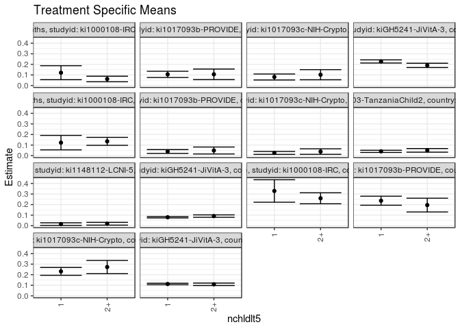

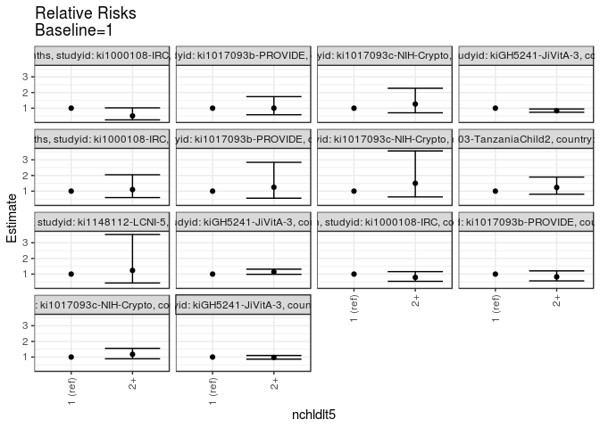

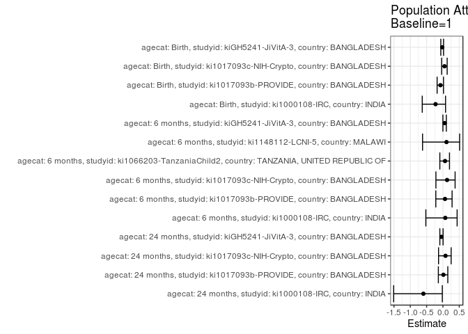

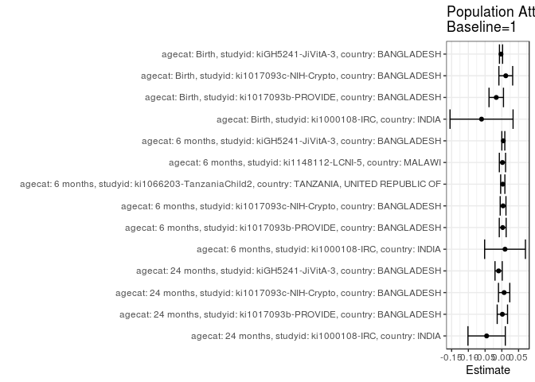

## Results Table

### Parameter: TSM

| agecat | studyid | country | intervention_level | baseline_level | estimate | ci_lower | ci_upper |
| --- | --- | --- | --- | --- | --- | --- | --- |
| Birth | ki1000108-IRC | INDIA | 1 | NA | 0.3288152 | 0.2223756 | 0.4352548 |
| Birth | ki1000108-IRC | INDIA | 2+ | NA | 0.2598253 | 0.2075858 | 0.3120647 |
| Birth | ki1017093b-PROVIDE | BANGLADESH | 1 | NA | 0.2365821 | 0.1937523 | 0.2794120 |
| Birth | ki1017093b-PROVIDE | BANGLADESH | 2+ | NA | 0.1953873 | 0.1304195 | 0.2603551 |
| Birth | ki1017093c-NIH-Crypto | BANGLADESH | 1 | NA | 0.2314894 | 0.1943660 | 0.2686128 |
| Birth | ki1017093c-NIH-Crypto | BANGLADESH | 2+ | NA | 0.2723756 | 0.2096889 | 0.3350623 |
| Birth | kiGH5241-JiVitA-3 | BANGLADESH | 1 | NA | 0.1120560 | 0.1050497 | 0.1190622 |
| Birth | kiGH5241-JiVitA-3 | BANGLADESH | 2+ | NA | 0.1093657 | 0.0979175 | 0.1208139 |
| 6 months | ki1000108-IRC | INDIA | 1 | NA | 0.1228179 | 0.0545862 | 0.1910496 |
| 6 months | ki1000108-IRC | INDIA | 2+ | NA | 0.1349966 | 0.0973749 | 0.1726183 |
| 6 months | ki1017093b-PROVIDE | BANGLADESH | 1 | NA | 0.0388128 | 0.0207093 | 0.0569163 |
| 6 months | ki1017093b-PROVIDE | BANGLADESH | 2+ | NA | 0.0484848 | 0.0156846 | 0.0812851 |
| 6 months | ki1017093c-NIH-Crypto | BANGLADESH | 1 | NA | 0.0256410 | 0.0118729 | 0.0394092 |
| 6 months | ki1017093c-NIH-Crypto | BANGLADESH | 2+ | NA | 0.0384615 | 0.0123088 | 0.0646143 |
| 6 months | ki1066203-TanzaniaChild2 | TANZANIA, UNITED REPUBLIC OF | 1 | NA | 0.0403122 | 0.0298877 | 0.0507367 |
| 6 months | ki1066203-TanzaniaChild2 | TANZANIA, UNITED REPUBLIC OF | 2+ | NA | 0.0497957 | 0.0326631 | 0.0669282 |
| 6 months | ki1148112-LCNI-5 | MALAWI | 1 | NA | 0.0153846 | 0.0031621 | 0.0276071 |
| 6 months | ki1148112-LCNI-5 | MALAWI | 2+ | NA | 0.0190024 | 0.0059523 | 0.0320524 |
| 6 months | kiGH5241-JiVitA-3 | BANGLADESH | 1 | NA | 0.0801261 | 0.0736106 | 0.0866415 |
| 6 months | kiGH5241-JiVitA-3 | BANGLADESH | 2+ | NA | 0.0912647 | 0.0797772 | 0.1027523 |
| 24 months | ki1000108-IRC | INDIA | 1 | NA | 0.1211787 | 0.0549811 | 0.1873763 |
| 24 months | ki1000108-IRC | INDIA | 2+ | NA | 0.0615862 | 0.0352366 | 0.0879357 |
| 24 months | ki1017093b-PROVIDE | BANGLADESH | 1 | NA | 0.1054597 | 0.0760572 | 0.1348621 |
| 24 months | ki1017093b-PROVIDE | BANGLADESH | 2+ | NA | 0.1058389 | 0.0558813 | 0.1557964 |
| 24 months | ki1017093c-NIH-Crypto | BANGLADESH | 1 | NA | 0.0806593 | 0.0524799 | 0.1088388 |
| 24 months | ki1017093c-NIH-Crypto | BANGLADESH | 2+ | NA | 0.1020233 | 0.0541899 | 0.1498567 |
| 24 months | kiGH5241-JiVitA-3 | BANGLADESH | 1 | NA | 0.2276638 | 0.2128085 | 0.2425192 |
| 24 months | kiGH5241-JiVitA-3 | BANGLADESH | 2+ | NA | 0.1905370 | 0.1704201 | 0.2106538 |

### Parameter: E(Y)

| agecat | studyid | country | intervention_level | baseline_level | estimate | ci_lower | ci_upper |
| --- | --- | --- | --- | --- | --- | --- | --- |
| Birth | ki1000108-IRC | INDIA | NA | NA | 0.2682216 | 0.2212677 | 0.3151755 |
| Birth | ki1017093b-PROVIDE | BANGLADESH | NA | NA | 0.2199248 | 0.1846953 | 0.2551543 |
| Birth | ki1017093c-NIH-Crypto | BANGLADESH | NA | NA | 0.2432815 | 0.2116319 | 0.2749310 |
| Birth | kiGH5241-JiVitA-3 | BANGLADESH | NA | NA | 0.1096659 | 0.1045396 | 0.1147922 |
| 6 months | ki1000108-IRC | INDIA | NA | NA | 0.1323529 | 0.0994307 | 0.1652752 |
| 6 months | ki1017093b-PROVIDE | BANGLADESH | NA | NA | 0.0414594 | 0.0255348 | 0.0573839 |
| 6 months | ki1017093c-NIH-Crypto | BANGLADESH | NA | NA | 0.0293706 | 0.0169860 | 0.0417552 |
| 6 months | ki1066203-TanzaniaChild2 | TANZANIA, UNITED REPUBLIC OF | NA | NA | 0.0430906 | 0.0342310 | 0.0519502 |
| 6 months | ki1148112-LCNI-5 | MALAWI | NA | NA | 0.0172626 | 0.0082929 | 0.0262323 |
| 6 months | kiGH5241-JiVitA-3 | BANGLADESH | NA | NA | 0.0846003 | 0.0797949 | 0.0894056 |
| 24 months | ki1000108-IRC | INDIA | NA | NA | 0.0757946 | 0.0501131 | 0.1014762 |
| 24 months | ki1017093b-PROVIDE | BANGLADESH | NA | NA | 0.1070812 | 0.0818727 | 0.1322897 |
| 24 months | ki1017093c-NIH-Crypto | BANGLADESH | NA | NA | 0.0875486 | 0.0630907 | 0.1120065 |
| 24 months | kiGH5241-JiVitA-3 | BANGLADESH | NA | NA | 0.2180845 | 0.2082032 | 0.2279658 |

### Parameter: RR

| agecat | studyid | country | intervention_level | baseline_level | estimate | ci_lower | ci_upper |
| --- | --- | --- | --- | --- | --- | --- | --- |
| Birth | ki1000108-IRC | INDIA | 1 | 1 | 1.0000000 | 1.0000000 | 1.0000000 |
| Birth | ki1000108-IRC | INDIA | 2+ | 1 | 0.7901864 | 0.5392943 | 1.1577992 |
| Birth | ki1017093b-PROVIDE | BANGLADESH | 1 | 1 | 1.0000000 | 1.0000000 | 1.0000000 |
| Birth | ki1017093b-PROVIDE | BANGLADESH | 2+ | 1 | 0.8258751 | 0.5658783 | 1.2053291 |
| Birth | ki1017093c-NIH-Crypto | BANGLADESH | 1 | 1 | 1.0000000 | 1.0000000 | 1.0000000 |
| Birth | ki1017093c-NIH-Crypto | BANGLADESH | 2+ | 1 | 1.1766223 | 0.8895342 | 1.5563650 |
| Birth | kiGH5241-JiVitA-3 | BANGLADESH | 1 | 1 | 1.0000000 | 1.0000000 | 1.0000000 |
| Birth | kiGH5241-JiVitA-3 | BANGLADESH | 2+ | 1 | 0.9759912 | 0.8653950 | 1.1007213 |
| 6 months | ki1000108-IRC | INDIA | 1 | 1 | 1.0000000 | 1.0000000 | 1.0000000 |
| 6 months | ki1000108-IRC | INDIA | 2+ | 1 | 1.0991608 | 0.5900682 | 2.0474830 |
| 6 months | ki1017093b-PROVIDE | BANGLADESH | 1 | 1 | 1.0000000 | 1.0000000 | 1.0000000 |
| 6 months | ki1017093b-PROVIDE | BANGLADESH | 2+ | 1 | 1.2491979 | 0.5492426 | 2.8411767 |
| 6 months | ki1017093c-NIH-Crypto | BANGLADESH | 1 | 1 | 1.0000000 | 1.0000000 | 1.0000000 |
| 6 months | ki1017093c-NIH-Crypto | BANGLADESH | 2+ | 1 | 1.5000000 | 0.6306811 | 3.5675717 |
| 6 months | ki1066203-TanzaniaChild2 | TANZANIA, UNITED REPUBLIC OF | 1 | 1 | 1.0000000 | 1.0000000 | 1.0000000 |
| 6 months | ki1066203-TanzaniaChild2 | TANZANIA, UNITED REPUBLIC OF | 2+ | 1 | 1.2352505 | 0.8031315 | 1.8998679 |
| 6 months | ki1148112-LCNI-5 | MALAWI | 1 | 1 | 1.0000000 | 1.0000000 | 1.0000000 |
| 6 months | ki1148112-LCNI-5 | MALAWI | 2+ | 1 | 1.2351544 | 0.4321632 | 3.5301627 |
| 6 months | kiGH5241-JiVitA-3 | BANGLADESH | 1 | 1 | 1.0000000 | 1.0000000 | 1.0000000 |
| 6 months | kiGH5241-JiVitA-3 | BANGLADESH | 2+ | 1 | 1.1390146 | 0.9864432 | 1.3151839 |
| 24 months | ki1000108-IRC | INDIA | 1 | 1 | 1.0000000 | 1.0000000 | 1.0000000 |
| 24 months | ki1000108-IRC | INDIA | 2+ | 1 | 0.5082260 | 0.2531539 | 1.0203030 |
| 24 months | ki1017093b-PROVIDE | BANGLADESH | 1 | 1 | 1.0000000 | 1.0000000 | 1.0000000 |
| 24 months | ki1017093b-PROVIDE | BANGLADESH | 2+ | 1 | 1.0035957 | 0.5795561 | 1.7378892 |
| 24 months | ki1017093c-NIH-Crypto | BANGLADESH | 1 | 1 | 1.0000000 | 1.0000000 | 1.0000000 |
| 24 months | ki1017093c-NIH-Crypto | BANGLADESH | 2+ | 1 | 1.2648666 | 0.7044818 | 2.2710133 |
| 24 months | kiGH5241-JiVitA-3 | BANGLADESH | 1 | 1 | 1.0000000 | 1.0000000 | 1.0000000 |
| 24 months | kiGH5241-JiVitA-3 | BANGLADESH | 2+ | 1 | 0.8369225 | 0.7389262 | 0.9479151 |

### Parameter: PAR

| agecat | studyid | country | intervention_level | baseline_level | estimate | ci_lower | ci_upper |
| --- | --- | --- | --- | --- | --- | --- | --- |
| Birth | ki1000108-IRC | INDIA | 1 | NA | -0.0605936 | -0.1547450 | 0.0335577 |
| Birth | ki1017093b-PROVIDE | BANGLADESH | 1 | NA | -0.0166573 | -0.0382443 | 0.0049296 |
| Birth | ki1017093c-NIH-Crypto | BANGLADESH | 1 | NA | 0.0117921 | -0.0087846 | 0.0323687 |
| Birth | kiGH5241-JiVitA-3 | BANGLADESH | 1 | NA | -0.0023900 | -0.0070640 | 0.0022839 |
| 6 months | ki1000108-IRC | INDIA | 1 | NA | 0.0095351 | -0.0513788 | 0.0704490 |
| 6 months | ki1017093b-PROVIDE | BANGLADESH | 1 | NA | 0.0026466 | -0.0076107 | 0.0129039 |
| 6 months | ki1017093c-NIH-Crypto | BANGLADESH | 1 | NA | 0.0037296 | -0.0048790 | 0.0123382 |
| 6 months | ki1066203-TanzaniaChild2 | TANZANIA, UNITED REPUBLIC OF | 1 | NA | 0.0027784 | -0.0035776 | 0.0091344 |
| 6 months | ki1148112-LCNI-5 | MALAWI | 1 | NA | 0.0018780 | -0.0074045 | 0.0111606 |
| 6 months | kiGH5241-JiVitA-3 | BANGLADESH | 1 | NA | 0.0044742 | 0.0000370 | 0.0089114 |
| 24 months | ki1000108-IRC | INDIA | 1 | NA | -0.0453841 | -0.1011620 | 0.0103938 |
| 24 months | ki1017093b-PROVIDE | BANGLADESH | 1 | NA | 0.0016215 | -0.0138223 | 0.0170654 |
| 24 months | ki1017093c-NIH-Crypto | BANGLADESH | 1 | NA | 0.0068893 | -0.0099771 | 0.0237557 |
| 24 months | kiGH5241-JiVitA-3 | BANGLADESH | 1 | NA | -0.0095793 | -0.0203861 | 0.0012274 |

### Parameter: PAF

| agecat | studyid | country | intervention_level | baseline_level | estimate | ci_lower | ci_upper |
| --- | --- | --- | --- | --- | --- | --- | --- |
| Birth | ki1000108-IRC | INDIA | 1 | NA | -0.2259088 | -0.6337598 | 0.0801265 |
| Birth | ki1017093b-PROVIDE | BANGLADESH | 1 | NA | -0.0757410 | -0.1782235 | 0.0178275 |
| Birth | ki1017093c-NIH-Crypto | BANGLADESH | 1 | NA | 0.0484708 | -0.0399904 | 0.1294076 |
| Birth | kiGH5241-JiVitA-3 | BANGLADESH | 1 | NA | -0.0217938 | -0.0653063 | 0.0199413 |
| 6 months | ki1000108-IRC | INDIA | 1 | NA | 0.0720428 | -0.5233430 | 0.4347271 |
| 6 months | ki1017093b-PROVIDE | BANGLADESH | 1 | NA | 0.0638356 | -0.2178857 | 0.2803892 |
| 6 months | ki1017093c-NIH-Crypto | BANGLADESH | 1 | NA | 0.1269841 | -0.2148048 | 0.3726097 |
| 6 months | ki1066203-TanzaniaChild2 | TANZANIA, UNITED REPUBLIC OF | 1 | NA | 0.0644789 | -0.0945760 | 0.2004212 |
| 6 months | ki1148112-LCNI-5 | MALAWI | 1 | NA | 0.1087912 | -0.6240960 | 0.5109568 |
| 6 months | kiGH5241-JiVitA-3 | BANGLADESH | 1 | NA | 0.0528863 | -0.0011090 | 0.1039693 |
| 24 months | ki1000108-IRC | INDIA | 1 | NA | -0.5987772 | -1.5088940 | -0.0188109 |
| 24 months | ki1017093b-PROVIDE | BANGLADESH | 1 | NA | 0.0151428 | -0.1401789 | 0.1493058 |
| 24 months | ki1017093c-NIH-Crypto | BANGLADESH | 1 | NA | 0.0786912 | -0.1342175 | 0.2516340 |
| 24 months | kiGH5241-JiVitA-3 | BANGLADESH | 1 | NA | -0.0439249 | -0.0946535 | 0.0044528 |